# Выявление закономерностей, определяющих успешность компьютерной игры.

Для того, чтобы магазин компьютерных игр смог спланировать рекламную кампанию на будующий год, сделав ставку на потенциально популярный продукт нам необходимо выявить закономерности, которые определяют успешность игры.

В нашем распоряжении имеются исторические данные из открытых источников. В них содержится информация о продажах игр, оценках пользователей и экспертов, жанрах игр и платформах (например Xbox или PlayStation).

```python
import pandas as pd
import matplotlib.pyplot as plt
import numpy as np
import warnings
from scipy import stats as st
warnings.filterwarnings('ignore')
```

## Обзор данных

```python
data = pd.read_csv('games.csv')
```

```python
data.info()
data.head(10)
```

```
<class 'pandas.core.frame.DataFrame'>
RangeIndex: 16715 entries, 0 to 16714
Data columns (total 11 columns):
 #   Column           Non-Null Count  Dtype
---  ------           --------------  -----
 0   Name             16713 non-null  object
 1   Platform         16715 non-null  object
 2   Year_of_Release  16446 non-null  float64
 3   Genre            16713 non-null  object
 4   NA_sales         16715 non-null  float64
 5   EU_sales         16715 non-null  float64
 6   JP_sales         16715 non-null  float64
 7   Other_sales      16715 non-null  float64
 8   Critic_Score     8137 non-null   float64
 9   User_Score       10014 non-null  object
 10  Rating           9949 non-null   object
dtypes: float64(6), object(5)
memory usage: 1.4+ MB
```

|  | Name | Platform | Year_of_Release | Genre | NA_sales | EU_sales | JP_sales | Other_sales | Critic_Score | User_Score | Rating |
| --- | --- | --- | --- | --- | --- | --- | --- | --- | --- | --- | --- |
| 0 | Wii Sports | Wii | 2006.0 | Sports | 41.36 | 28.96 | 3.77 | 8.45 | 76.0 | 8 | E |
| 1 | Super Mario Bros. | NES | 1985.0 | Platform | 29.08 | 3.58 | 6.81 | 0.77 | NaN | NaN | NaN |
| 2 | Mario Kart Wii | Wii | 2008.0 | Racing | 15.68 | 12.76 | 3.79 | 3.29 | 82.0 | 8.3 | E |
| 3 | Wii Sports Resort | Wii | 2009.0 | Sports | 15.61 | 10.93 | 3.28 | 2.95 | 80.0 | 8 | E |
| 4 | Pokemon Red/Pokemon Blue | GB | 1996.0 | Role-Playing | 11.27 | 8.89 | 10.22 | 1.00 | NaN | NaN | NaN |
| 5 | Tetris | GB | 1989.0 | Puzzle | 23.20 | 2.26 | 4.22 | 0.58 | NaN | NaN | NaN |
| 6 | New Super Mario Bros. | DS | 2006.0 | Platform | 11.28 | 9.14 | 6.50 | 2.88 | 89.0 | 8.5 | E |
| 7 | Wii Play | Wii | 2006.0 | Misc | 13.96 | 9.18 | 2.93 | 2.84 | 58.0 | 6.6 | E |
| 8 | New Super Mario Bros. Wii | Wii | 2009.0 | Platform | 14.44 | 6.94 | 4.70 | 2.24 | 87.0 | 8.4 | E |
| 9 | Duck Hunt | NES | 1984.0 | Shooter | 26.93 | 0.63 | 0.28 | 0.47 | NaN | NaN | NaN |

Таблица содержит 11 столбцов, тип данных в шести из них `float`, в пяти `object`

Согласно документации к данным:

- `Name` - название игры,
- `Platform` - платформа,
- `Year_of_Release` - год выпуска,
- `Genre` - жанр игры,
- `NA_sales` - продажи в Северной Америке (миллионы проданных копий),
- `EU_sales` - продажи в Европе (миллионы проданных копий),
- `JP_sales` - продажи в Японии (миллионы проданных копий),
- `Other_sales` - продажи в других странах (миллионы проданных копий),
- `Critic_Score` - оценка критиков (максимум 100),
- `User_Score` - оценка пользователей (максимум 10),
- `Rating` - рейтинг от организации *ESRB*.

В названиях столбцов есть нарушение стиля, а именно: строчные буквы сочетаются с прописными. Формат столбца `Year_of_Release` вещественный (`float`), но он содержит год выпуска игры и его формат должен быть `datetime`. Также столбец с оценками пользователей имеет формат `object`, хотя, если основываться на описании данных, должен быть в формате `float`.

В таблице всего 16715 строк. В шести столбцах имеются незаполненные значения (название, год выпуска, жанр, оценка критиков, оценка пользователей и рейтинг). Больше всего пропусков в столбце `Critic_Score` - не заполнено больше половины строк.

Посмотрим на имеющиеся данные, применив метод `describe`

```python
data.describe().T
```

|  | count | mean | std | min | 25% | 50% | 75% | max |
| --- | --- | --- | --- | --- | --- | --- | --- | --- |
| Year_of_Release | 16446.0 | 2006.484616 | 5.877050 | 1980.0 | 2003.0 | 2007.00 | 2010.00 | 2016.00 |
| NA_sales | 16715.0 | 0.263377 | 0.813604 | 0.0 | 0.0 | 0.08 | 0.24 | 41.36 |
| EU_sales | 16715.0 | 0.145060 | 0.503339 | 0.0 | 0.0 | 0.02 | 0.11 | 28.96 |
| JP_sales | 16715.0 | 0.077617 | 0.308853 | 0.0 | 0.0 | 0.00 | 0.04 | 10.22 |
| Other_sales | 16715.0 | 0.047342 | 0.186731 | 0.0 | 0.0 | 0.01 | 0.03 | 10.57 |
| Critic_Score | 8137.0 | 68.967679 | 13.938165 | 13.0 | 60.0 | 71.00 | 79.00 | 98.00 |

**Выводы**

Таблица содержит данные об играх, выпущенных за период с 1980 по 2016 годы.

Каждая строка таблицы содержит информацию о названии игры, для какой платформы она выпущена, в каком году, какому жанру соответствует. Далее идет информация о продажах (в Северной Америке, Европе, Японии и других странах), а также оценке критиков и пользователей, и рейтинг от *ESRB*.

Предварительно можно утверждать, что данных для проведения исследования достаточно. Однако в них встречается много пропусков, названия столбцов таблицы не соответствуют хорошему стилю, а форматы данных некоторых столбцов не соответствуют содержащейся в них информации.

Первоначально необходимо устранить проблемы в данных.

## Подготовка данных

### Стиль заголовков

Приведем все буквы в названиях столбцов к нижнему регистру.

```python
data.columns
```

```
Index(['Name', 'Platform', 'Year_of_Release', 'Genre', 'NA_sales', 'EU_sales',
       'JP_sales', 'Other_sales', 'Critic_Score', 'User_Score', 'Rating'],
      dtype='object')
```

```python
data.columns = data.columns.str.lower()
```

Проверим результат

```python
data.columns
```

```
Index(['name', 'platform', 'year_of_release', 'genre', 'na_sales', 'eu_sales',
       'jp_sales', 'other_sales', 'critic_score', 'user_score', 'rating'],
      dtype='object')
```

### Преобразование данных.

Как мы уже выяснили нам необходимо преобразовать столбец `year_of_release` в формат `datetime`, а столбец `user_score` в формат `float`.

**Столбец `year_of_release`**

```python
DATE_FORMAT = '%Y'
data['year_of_release'] = pd.to_datetime(data['year_of_release'], format=DATE_FORMAT )

data['year_of_release'].dtypes
data['year_of_release'].head(10)
```

```
0   2006-01-01
1   1985-01-01
2   2008-01-01
3   2009-01-01
4   1996-01-01
5   1989-01-01
6   2006-01-01
7   2006-01-01
8   2009-01-01
9   1984-01-01
Name: year_of_release, dtype: datetime64[ns]
```

Для того, чтобы отображался только год выхода игры зададим формат `period`

```python
data['year_of_release'] = data['year_of_release'].dt.to_period('Y')
```

Проверим результата

```python
print('Формат столбца"year_of_release" после преобразования', data['year_of_release'].dtypes)
data['year_of_release'].head()
```

```
Формат столбца"year_of_release" после преобразования period[A-DEC]
```

```
0    2006
1    1985
2    2008
3    2009
4    1996
Name: year_of_release, dtype: period[A-DEC]
```

**Столбец `user_score`**

Посмотрим на все уникальные значения в столбце.

```python
data['user_score'].unique()
```

```
array(['8', nan, '8.3', '8.5', '6.6', '8.4', '8.6', '7.7', '6.3', '7.4',
       '8.2', '9', '7.9', '8.1', '8.7', '7.1', '3.4', '5.3', '4.8', '3.2',
       '8.9', '6.4', '7.8', '7.5', '2.6', '7.2', '9.2', '7', '7.3', '4.3',
       '7.6', '5.7', '5', '9.1', '6.5', 'tbd', '8.8', '6.9', '9.4', '6.8',
       '6.1', '6.7', '5.4', '4', '4.9', '4.5', '9.3', '6.2', '4.2', '6',
       '3.7', '4.1', '5.8', '5.6', '5.5', '4.4', '4.6', '5.9', '3.9',
       '3.1', '2.9', '5.2', '3.3', '4.7', '5.1', '3.5', '2.5', '1.9', '3',
       '2.7', '2.2', '2', '9.5', '2.1', '3.6', '2.8', '1.8', '3.8', '0',
       '1.6', '9.6', '2.4', '1.7', '1.1', '0.3', '1.5', '0.7', '1.2',
       '2.3', '0.5', '1.3', '0.2', '0.6', '1.4', '0.9', '1', '9.7'],
      dtype=object)
```

Помимо пропусков и числовых оценок, столбец содержит значение `tbd`. Посмотрим на строки с этим значением оценки пользователей.

```python
print('Значение "tbd" в оценке пользователей содержит', len(data.query('user_score == "tbd"')), 'строк')
data.query('user_score == "tbd"').sample(10)
```

```
Значение "tbd" в оценке пользователей содержит 2424 строк
```

|  | name | platform | year_of_release | genre | na_sales | eu_sales | jp_sales | other_sales | critic_score | user_score | rating |
| --- | --- | --- | --- | --- | --- | --- | --- | --- | --- | --- | --- |
| 13422 | Mike Tyson Heavyweight Boxing | XB | 2002 | Sports | 0.03 | 0.01 | 0.0 | 0.00 | 37.0 | tbd | T |
| 8225 | World Championship Poker | GBA | 2004 | Misc | 0.12 | 0.05 | 0.0 | 0.00 | 66.0 | tbd | E |
| 12408 | Tron 2.0: Killer App | GBA | 2004 | Action | 0.04 | 0.02 | 0.0 | 0.00 | 68.0 | tbd | E |
| 10574 | SimAnimals Africa | DS | 2009 | Simulation | 0.08 | 0.02 | 0.0 | 0.01 | NaN | tbd | E |
| 8515 | Dancing With The Stars | PS2 | 2007 | Misc | 0.08 | 0.06 | 0.0 | 0.02 | NaN | tbd | E10+ |
| 9625 | Shimano Xtreme Fishing | Wii | 2009 | Sports | 0.12 | 0.00 | 0.0 | 0.01 | NaN | tbd | T |
| 8770 | Gunslingers | Wii | 2010 | Shooter | 0.07 | 0.06 | 0.0 | 0.02 | NaN | tbd | T |
| 6361 | NASCAR Thunder 2003 | XB | 2002 | Racing | 0.20 | 0.06 | 0.0 | 0.01 | 84.0 | tbd | E |
| 15438 | Jake Hunter: Detective Chronicles | DS | 2008 | Adventure | 0.02 | 0.00 | 0.0 | 0.00 | 47.0 | tbd | T |
| 15287 | Dream Chronicles | DS | 2010 | Adventure | 0.02 | 0.00 | 0.0 | 0.00 | NaN | tbd | E |

```python
print(data.loc[data['user_score'] == 'tbd', 'na_sales'].max())
print(data.loc[data['user_score'] == 'tbd', 'eu_sales'].max())
print(data.loc[data['user_score'] == 'tbd', 'jp_sales'].max())
print(data.loc[data['user_score'] == 'tbd', 'year_of_release'].max())
print(data.loc[data['user_score'] == 'tbd', 'year_of_release'].min())
```

```
3.45
2.59
0.86
2016
1997
```

Данная аббревиатура буквально означает "подлежит обсуждению". При рассмотрении строк таблицы, содержащих `tbd` в оценке пользователей, каких-то характерных особенностей не выявлено. В нашем случае можем сделать вывод, что оценка пользователей по играм, с указанным значением столбца `user_score` не определена. Заменим значение `tbd` на пропуски.

```python
data.loc[data['user_score'] == 'tbd', 'user_score'] = float('nan')
```

Проверим результат

```python
data['user_score'].unique()
```

```
array(['8', nan, '8.3', '8.5', '6.6', '8.4', '8.6', '7.7', '6.3', '7.4',
       '8.2', '9', '7.9', '8.1', '8.7', '7.1', '3.4', '5.3', '4.8', '3.2',
       '8.9', '6.4', '7.8', '7.5', '2.6', '7.2', '9.2', '7', '7.3', '4.3',
       '7.6', '5.7', '5', '9.1', '6.5', '8.8', '6.9', '9.4', '6.8', '6.1',
       '6.7', '5.4', '4', '4.9', '4.5', '9.3', '6.2', '4.2', '6', '3.7',
       '4.1', '5.8', '5.6', '5.5', '4.4', '4.6', '5.9', '3.9', '3.1',
       '2.9', '5.2', '3.3', '4.7', '5.1', '3.5', '2.5', '1.9', '3', '2.7',
       '2.2', '2', '9.5', '2.1', '3.6', '2.8', '1.8', '3.8', '0', '1.6',
       '9.6', '2.4', '1.7', '1.1', '0.3', '1.5', '0.7', '1.2', '2.3',
       '0.5', '1.3', '0.2', '0.6', '1.4', '0.9', '1', '9.7'], dtype=object)
```

Теперь можно преобразовать формат столбца в `float`

```python
data['user_score'] = data['user_score'].astype('float')
print('Формат столбца "user_score" после преобразования', data['user_score'].dtypes)
```

```
Формат столбца "user_score" после преобразования float64
```

Из списка уникальных значений видно, что в таблице есть игры с 0 оценкой пользователей. Посмотрим на них, может это ошибка данных.

```python
data.loc[data['user_score'] == 0]
```

|  | name | platform | year_of_release | genre | na_sales | eu_sales | jp_sales | other_sales | critic_score | user_score | rating |
| --- | --- | --- | --- | --- | --- | --- | --- | --- | --- | --- | --- |
| 2835 | My Little Pony: Pinkie Pie's Party | DS | 2008 | Adventure | 0.66 | 0.0 | 0.0 | 0.06 | NaN | 0.0 | E |

Такая игра всего одна, даже если значение ошибочно, результаты исследования это не исказит. Оставим строку с этим значением.

### Заполнение пропусков.

Пропуски в столбцах, содержащих числовые значения `critic_score`, `user_score` заполнять не будем. Пропусков достаточно много и их заполнение может исказить результаты исследования. Поскольку данные собирались из открытых источников, возможно информации об оценках не нашли в свободном доступе, по играм, вышедшим достаточно давно возможно оценок не было.

Пропуски в столбце `year_of_release` также заполнять не будем. Таких строк всего 269 из 16715, т.е. 1,6 %. Их можно будет удалить или отфильтровать. Возможная причина появления этих пропусков некрректный перенос данных, возможно в источнике информации дата выхода не была выделена отдельно.

Столбец с названием игры содержит 2 пропущенных значения, также два пропущенных значения содержит столбец с жанром игры. Возможно это одни и те же строки.

```python
data.loc[data['name'].isna()]
```

|  | name | platform | year_of_release | genre | na_sales | eu_sales | jp_sales | other_sales | critic_score | user_score | rating |
| --- | --- | --- | --- | --- | --- | --- | --- | --- | --- | --- | --- |
| 659 | NaN | GEN | 1993 | NaN | 1.78 | 0.53 | 0.00 | 0.08 | NaN | NaN | NaN |
| 14244 | NaN | GEN | 1993 | NaN | 0.00 | 0.00 | 0.03 | 0.00 | NaN | NaN | NaN |

Как видно это игры, для одной платформы, одного года выпуска. Пропуски могли возникнуть в результате ошибки выгрузки данных.Мы можем удалить эти строки, тут нет данных ни по оценкам, ни по рейтингам. Удаление этих строк не исказит результаты исследования.

```python
print('Пропущенные значения в столбце "name" до', len(data.loc[data['name'].isna()]))
data = data.loc[~data['name'].isna()]
print('Пропущенные значения в столбце "name" после', len(data.loc[data['name'].isna()]))
print('Пропущенные значения в столбце "genre" после', len(data.loc[data['genre'].isna()]))
```

```
Пропущенные значения в столбце "name" до 2
Пропущенные значения в столбце "name" после 0
Пропущенные значения в столбце "genre" после 0
```

Пропуски в столбце `rating` возможны из-за отсутствия этого значения для многих игр. Этот рейтинг начали присваивать играм только с 1994 г., а у нас данные с 1980 г., также вполне вероятно, что этот рейтинг был присвоен не всем играм и после 1994 г. Поэтому пропуски в этом столбце заполним значением `undefined`.

```python
print('Пропущенные значения в столбце "rating" до', len(data.loc[data['rating'].isna()]))
data.loc[data['rating'].isna(), 'rating'] = 'undefined'
print('Пропущенные значения в столбце "rating" после', len(data.loc[data['rating'].isna()]))
```

```
Пропущенные значения в столбце "rating" до 6764
Пропущенные значения в столбце "rating" после 0
```

Данные, заполнение или удаление пропусков по которым не исказит результаты исследования, мы исправили.

```python
data.info()
```

```
<class 'pandas.core.frame.DataFrame'>
Int64Index: 16713 entries, 0 to 16714
Data columns (total 11 columns):
 #   Column           Non-Null Count  Dtype
---  ------           --------------  -----
 0   name             16713 non-null  object
 1   platform         16713 non-null  object
 2   year_of_release  16444 non-null  period[A-DEC]
 3   genre            16713 non-null  object
 4   na_sales         16713 non-null  float64
 5   eu_sales         16713 non-null  float64
 6   jp_sales         16713 non-null  float64
 7   other_sales      16713 non-null  float64
 8   critic_score     8137 non-null   float64
 9   user_score       7590 non-null   float64
 10  rating           16713 non-null  object
dtypes: float64(6), object(4), period[A-DEC](1)
memory usage: 1.5+ MB
```

### Добавление столбца с суммарными продажами.

Посчитаем суммарные продажи игр по всем регионам и добавим данные в отдельный столбец.

```python
data['total_sales'] = data['na_sales'] + data['eu_sales'] + data['jp_sales'] + data['other_sales']

data.head()
```

|  | name | platform | year_of_release | genre | na_sales | eu_sales | jp_sales | other_sales | critic_score | user_score | rating | total_sales |
| --- | --- | --- | --- | --- | --- | --- | --- | --- | --- | --- | --- | --- |
| 0 | Wii Sports | Wii | 2006 | Sports | 41.36 | 28.96 | 3.77 | 8.45 | 76.0 | 8.0 | E | 82.54 |
| 1 | Super Mario Bros. | NES | 1985 | Platform | 29.08 | 3.58 | 6.81 | 0.77 | NaN | NaN | undefined | 40.24 |
| 2 | Mario Kart Wii | Wii | 2008 | Racing | 15.68 | 12.76 | 3.79 | 3.29 | 82.0 | 8.3 | E | 35.52 |
| 3 | Wii Sports Resort | Wii | 2009 | Sports | 15.61 | 10.93 | 3.28 | 2.95 | 80.0 | 8.0 | E | 32.77 |
| 4 | Pokemon Red/Pokemon Blue | GB | 1996 | Role-Playing | 11.27 | 8.89 | 10.22 | 1.00 | NaN | NaN | undefined | 31.38 |

```python
data.duplicated().sum()
```

```
0
```

### Вывод.

В ходе обзора данных мы выявили следующие проблемы:

- нарушения в стиле заголовков;
- пропущенные значения;
- несоответствие форматов данных в столбцах описанию.

Мы исправили заголовки столбцов для удобства работы с таблицей. Выяснили, что в большинстве случаев мы не можем заполнить пропуски, т.к. это может привести к искажению результатов анализа. Возможно, большое количество пропусков в столбцах `critic_score` и `user_score` повредит проведению исследования.

Мы заполнили пропуски в столбце `rating` значением `undefined`, удалили строки, в которых не заполненны название и жанр игры (их было всего две). Заменив в столбце `user_score` значение `tbd` на `nan`, смогли преобразовать формат этого столбца в `float`. Кроме того, мы преобразовали формат столбца `year_of_release` в `period`, что соответствует представленной в нем информации.

Для дальнейшего анализа данных, добавили к таблице столбец с суммарным значением продаж по игре.

В целом мы можем приступить к исследованию данных.

## Исследовательский анализ данных.

### Определение актуального периода для исследования.

#### Выпуск игр по годам

Посмотрим сколько игр выпускалось в разные годы.

Чтобы данные были наглядней, построим график на основе имеющихся данных.

```python
display(data.groupby('year_of_release').agg({'name' : 'count'}).T)
```

| year_of_release | 1980 | 1981 | 1982 | 1983 | 1984 | 1985 | 1986 | 1987 | 1988 | 1989 | ... | 2007 | 2008 | 2009 | 2010 | 2011 | 2012 | 2013 | 2014 | 2015 | 2016 |
| --- | --- | --- | --- | --- | --- | --- | --- | --- | --- | --- | --- | --- | --- | --- | --- | --- | --- | --- | --- | --- | --- |
| name | 9 | 46 | 36 | 17 | 14 | 14 | 21 | 16 | 15 | 17 | ... | 1197 | 1427 | 1426 | 1255 | 1136 | 653 | 544 | 581 | 606 | 502 |

1 rows × 37 columns

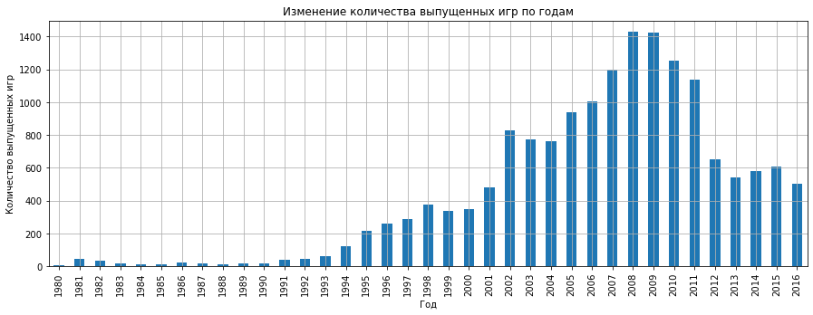

```python
data.groupby('year_of_release').agg({'name' : 'count'}).plot(kind='bar',
                                                             y='name',
                                                             figsize=(15,5),
                                                             grid=True,
                                                             legend=False)
plt.title('Изменение количества выпущенных игр по годам')
plt.ylabel('Количество выпущенных игр')
plt.xlabel('Год')
plt.show()
```

На полученном графике мы видим, что в период с 1980 по 1993 годы выпускалось менее 100 компьютерных игр в год. Начиная с 1994 года наблюдается значительный прирост количества выпущенных игр. В период с 2005 по 2011 года выпускается наибольшее количество компьютерных игр. Максимум достигнут в 2008, 2009 годах (более 1400 игр в год). В 2012 году количество выпускаемых игр резко сокращается с 1136 в 2011г. до 653 (на 43%). И начиная с 2013 года количество выпускаемых компьютерных игр сохраняется на уровне от 500 до 600 в год.

Можно предположить, что для нашего исследования будут важны данные за последние 4 года (2013-2016).

#### Распределение продаж игр по годам в зависимости от платформы.

Для более точного определения актуального периода посмотрим на продажи по годам в зависимости от платформы. Для этого выберем платформы с наибольшими суммарными продажами.

```python
platform_max_sales =(
    data.groupby('platform').agg({'total_sales' : 'sum'}).sort_values(by='total_sales', ascending=False).head(10)
)
platform_max_sales
```

| platform | total_sales |
| --- | --- |
| PS2 | 1255.77 |
| X360 | 971.42 |
| PS3 | 939.65 |
| Wii | 907.51 |
| DS | 806.12 |
| PS | 730.86 |
| GBA | 317.85 |
| PS4 | 314.14 |
| PSP | 294.05 |
| PC | 259.52 |

Построим график распределения продаж по годам по выбранным платформам.

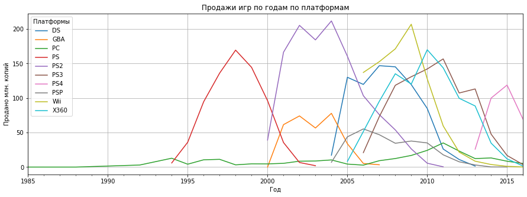

```python
platform_max_sales = platform_max_sales.index

(data.query('platform in @platform_max_sales')
 .pivot_table(index='year_of_release', columns='platform', values='total_sales', aggfunc='sum')
 .plot(kind='line', figsize=(15,5), grid=True)
)
plt.title('Продажи игр по годам по платформам')
plt.legend(title='Платформы')
plt.ylabel('Продано млн. копий')
plt.xlabel('Год')
plt.show()
```

На графике видно, что в целом платформы существуют 7-12 лет. Пять из десяти платформ, попавших в отбор появились в 2004-2007 г. Период высоких продаж игр по этим платформам как-раз пришелся на 2008-2009 года, которым соответствует наибольшее количество выпущенных игр.

Исключение составляют игры, выпущенные для персональных компьютеров(платформа "PC"). Количество продаж по ним значительно меньше, чем по остальным платформам, но они распределены более равномерно на протяжении всего периода. Заметный рост в их продажах наблюдается с 2008 по 2011 годы, затем продажи опять постепенно сокращаются.

Проверим выводы сделанные по графику, рассчитав средний период жизни платформ. Периодом жизни будем считать время, когда продажи игр на этой платформе превышают 1 млн.

```python
actual_period=(
    data.groupby(['platform', 'year_of_release']).agg({'total_sales' : sum})
    .query('platform in @platform_max_sales and total_sales > 1')
)
actual_period = actual_period.reset_index().groupby('platform').agg({'year_of_release' : 'count'})
display(actual_period)
print()
print('Средний период жизни игровой платформы', actual_period['year_of_release'].mean(), 'лет')
```

| platform | year_of_release |
| --- | --- |
| DS | 10 |
| GBA | 7 |
| PC | 24 |
| PS | 10 |
| PS2 | 11 |
| PS3 | 11 |
| PS4 | 4 |
| PSP | 10 |
| Wii | 10 |
| X360 | 12 |

```
Средний период жизни игровой платформы 10.9 лет
```

Расчеты поддверждают наши выводы.

**Вывод**

Поскольку построенный график показывает, что максимальных продаж игр платформы достигают примерно на 2-5 годах своего существования, а также ориентируясь на данные по выпущенным играм (где виден резкий спад начиная с 2012 года.), определим актуальный период для нашего исследования 2013-2016 года.

### Исследование продаж игр в актуальном периоде (2013-2016 годы)

Отфильтруем из таблицы данные за актуальный период.

```python
data_actual = data.query('year_of_release >= "2013"')
data_actual.info()
data_actual.head(10)
```

```
<class 'pandas.core.frame.DataFrame'>
Int64Index: 2233 entries, 16 to 16714
Data columns (total 12 columns):
 #   Column           Non-Null Count  Dtype
---  ------           --------------  -----
 0   name             2233 non-null   object
 1   platform         2233 non-null   object
 2   year_of_release  2233 non-null   period[A-DEC]
 3   genre            2233 non-null   object
 4   na_sales         2233 non-null   float64
 5   eu_sales         2233 non-null   float64
 6   jp_sales         2233 non-null   float64
 7   other_sales      2233 non-null   float64
 8   critic_score     991 non-null    float64
 9   user_score       1192 non-null   float64
 10  rating           2233 non-null   object
 11  total_sales      2233 non-null   float64
dtypes: float64(7), object(4), period[A-DEC](1)
memory usage: 226.8+ KB
```

|  | name | platform | year_of_release | genre | na_sales | eu_sales | jp_sales | other_sales | critic_score | user_score | rating | total_sales |
| --- | --- | --- | --- | --- | --- | --- | --- | --- | --- | --- | --- | --- |
| 16 | Grand Theft Auto V | PS3 | 2013 | Action | 7.02 | 9.09 | 0.98 | 3.96 | 97.0 | 8.2 | M | 21.05 |
| 23 | Grand Theft Auto V | X360 | 2013 | Action | 9.66 | 5.14 | 0.06 | 1.41 | 97.0 | 8.1 | M | 16.27 |
| 31 | Call of Duty: Black Ops 3 | PS4 | 2015 | Shooter | 6.03 | 5.86 | 0.36 | 2.38 | NaN | NaN | undefined | 14.63 |
| 33 | Pokemon X/Pokemon Y | 3DS | 2013 | Role-Playing | 5.28 | 4.19 | 4.35 | 0.78 | NaN | NaN | undefined | 14.60 |
| 42 | Grand Theft Auto V | PS4 | 2014 | Action | 3.96 | 6.31 | 0.38 | 1.97 | 97.0 | 8.3 | M | 12.62 |
| 47 | Pokemon Omega Ruby/Pokemon Alpha Sapphire | 3DS | 2014 | Role-Playing | 4.35 | 3.49 | 3.10 | 0.74 | NaN | NaN | undefined | 11.68 |
| 60 | Call of Duty: Ghosts | X360 | 2013 | Shooter | 6.73 | 2.56 | 0.04 | 0.91 | 73.0 | 2.6 | M | 10.24 |
| 69 | Call of Duty: Ghosts | PS3 | 2013 | Shooter | 4.10 | 3.63 | 0.38 | 1.25 | 71.0 | 2.6 | M | 9.36 |
| 72 | Minecraft | X360 | 2013 | Misc | 5.70 | 2.65 | 0.02 | 0.81 | NaN | NaN | undefined | 9.18 |
| 77 | FIFA 16 | PS4 | 2015 | Sports | 1.12 | 6.12 | 0.06 | 1.28 | 82.0 | 4.3 | E | 8.58 |

Посмотрим на общую статистику в актуальном периоде.

```python
data_actual.describe()
```

|  | na_sales | eu_sales | jp_sales | other_sales | critic_score | user_score | total_sales |
| --- | --- | --- | --- | --- | --- | --- | --- |
| count | 2233.000000 | 2233.000000 | 2233.000000 | 2233.000000 | 991.000000 | 1192.000000 | 2233.000000 |
| mean | 0.196019 | 0.175652 | 0.063045 | 0.053726 | 72.023209 | 6.584564 | 0.488442 |
| std | 0.547730 | 0.512451 | 0.233997 | 0.165693 | 12.841318 | 1.610413 | 1.235226 |
| min | 0.000000 | 0.000000 | 0.000000 | 0.000000 | 13.000000 | 0.200000 | 0.010000 |
| 25% | 0.000000 | 0.000000 | 0.000000 | 0.000000 | 66.000000 | 5.800000 | 0.030000 |
| 50% | 0.020000 | 0.030000 | 0.010000 | 0.010000 | 74.000000 | 7.000000 | 0.110000 |
| 75% | 0.150000 | 0.130000 | 0.050000 | 0.040000 | 81.000000 | 7.800000 | 0.400000 |
| max | 9.660000 | 9.090000 | 4.350000 | 3.960000 | 97.000000 | 9.300000 | 21.050000 |

#### Анализ продаж по платформам.

**Структура продаж по платформам в актуальном периоде.**

Посмотрим на скольки платформах выпускаются игры в актуальном периоде.

```python
print('В актуальный период выпускаются игры на', len(data_actual['platform'].unique()), 'платформах')

data_actual['platform'].sort_values().unique()
```

```
В актуальный период выпускаются игры на 11 платформах
```

```
array(['3DS', 'DS', 'PC', 'PS3', 'PS4', 'PSP', 'PSV', 'Wii', 'WiiU',
       'X360', 'XOne'], dtype=object)
```

В актуальном периоде продаются игры на 11 платформах. Построим графики распределения продаж по платформам по годам.

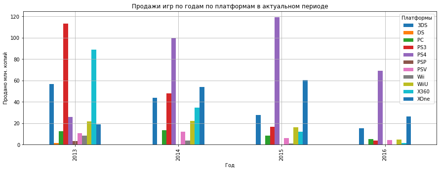

```python
(data_actual.pivot_table(index='year_of_release', columns='platform', values='total_sales', aggfunc='sum')
 .plot(kind='bar', figsize=(15,5), grid=True)
)
plt.title('Продажи игр по годам по платформам в актуальном периоде')
plt.legend(title='Платформы')
plt.ylabel('Продано млн. копий')
plt.xlabel('Год')
plt.show()
```

Посмотрим как меняются по годам доли продаж игр по платфомам, независимо от общего роста или спада продаж.

Построим график и таблицу с итоговыми данными по годам и долями каждой платформы.

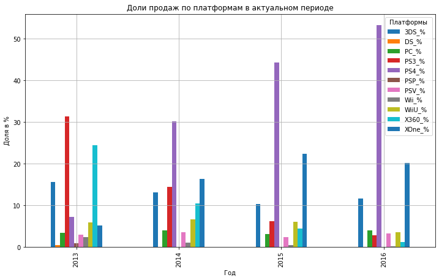

| platform year_of_release | 3DS_% | DS_% | PC_% | PS3_% | PS4_% | PSP_% | PSV_% | Wii_% | WiiU_% | X360_% | XOne_% |
| --- | --- | --- | --- | --- | --- | --- | --- | --- | --- | --- | --- |
| 2013 | 15.66 | 0.43 | 3.43 | 31.35 | 7.19 | 0.87 | 2.93 | 2.38 | 5.99 | 24.52 | 5.25 |
| 2014 | 13.20 | NaN | 4.01 | 14.41 | 30.16 | 0.07 | 3.59 | 1.13 | 6.64 | 10.48 | 16.31 |
| 2015 | 10.37 | NaN | 3.18 | 6.28 | 44.37 | 0.04 | 2.33 | 0.43 | 6.10 | 4.46 | 22.44 |
| 2016 | 11.65 | NaN | 4.04 | 2.77 | 53.29 | NaN | 3.27 | 0.14 | 3.54 | 1.17 | 20.12 |

```python
platform_sales = data_actual.pivot_table(index='year_of_release', columns='platform', values='total_sales', aggfunc='sum')
platform_sales['total_sales']=platform_sales.loc[:, '3DS':'XOne'].sum(axis=1)
platform_sales['3DS_%'] = round((platform_sales['3DS'] / platform_sales['total_sales'] *100), 2)
platform_sales['DS_%'] = round((platform_sales['DS'] / platform_sales['total_sales'] *100), 2)
platform_sales['PC_%'] = round((platform_sales['PC'] / platform_sales['total_sales'] *100), 2)
platform_sales['PS3_%'] = round((platform_sales['PS3'] / platform_sales['total_sales'] *100), 2)
platform_sales['PS4_%'] = round((platform_sales['PS4'] / platform_sales['total_sales'] *100), 2)
platform_sales['PSP_%'] = round((platform_sales['PSP'] / platform_sales['total_sales'] *100), 2)
platform_sales['PSV_%'] = round((platform_sales['PSV'] / platform_sales['total_sales'] *100), 2)
platform_sales['Wii_%'] = round((platform_sales['Wii'] / platform_sales['total_sales'] *100), 2)
platform_sales['WiiU_%'] = round((platform_sales['WiiU'] / platform_sales['total_sales'] *100), 2)
platform_sales['X360_%'] = round((platform_sales['X360'] / platform_sales['total_sales'] *100), 2)
platform_sales['XOne_%'] = round((platform_sales['XOne'] / platform_sales['total_sales'] *100), 2)

platform_sales_per = platform_sales.loc[:,'3DS_%':'XOne_%']

(platform_sales_per
 .plot(kind='bar', figsize=(12,7), grid=True)
)
plt.title('Доли продаж по платформам в актуальном периоде')
plt.legend(title='Платформы')
plt.ylabel('Доля в %')
plt.xlabel('Год')
plt.show()


platform_sales_per
```

На этом графике явно виден рост доли продаж по PS4 и XOne, небольшой рост в 2016 г. доли платформы 3DS, и сокращение по остальным платформам, кроме PC. Еще одна платформа с небольшой, но стабильной долей в продажах PSV.

В общем самыми потенциально прибыльными платформами можно назвать PS4 и XOne, еще стоит обратить внимание на платформы 3DS и PC, чьи продажи достаточно стабильны, по сравнению с другими платформами.

**Разброс значений глобальных продаж в разбивке по платформам.**

Для оценки разброса величины продаж в зависимости от платформы построим график "ящик с усами" по глобальным продажам игр в разбивке по платформам.

Для более корректного изображения графика построим его в пределах, немногим больше пределов нормальных значений для платформы с максимальными продажами (PS4).

Посчитаем эти пределы

```python
def normal_borders(df, column):
    left_border=df[column].quantile(0.25)-1.5*(df[column].quantile(0.75)-df[column].quantile(0.25))
    right_border=df[column].quantile(0.75)+1.5*(df[column].quantile(0.75)-df[column].quantile(0.25))
    if left_border < 0:
        left_border = 0
    return left_border, right_border
```

```python
normal_borders(data_actual.loc[data_actual['platform'] == 'PS4'], 'total_sales')
```

```
(0, 1.7349999999999999)
```

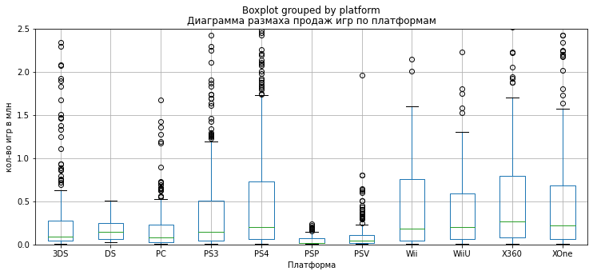

```python
data_actual.boxplot(column='total_sales', by='platform', figsize=(12,5));
plt.title('Диаграмма размаха продаж игр по платформам')
plt.ylabel('кол-во игр в млн')
plt.xlabel('Платформа')


plt.ylim(0 ,2.5)
plt.show()
```

Для большей наглядности посчитаем медианы по продажам игр для каждой платформы.

```python
data_actual.groupby('platform').agg({'total_sales' : 'median'}).sort_values(by='total_sales', ascending=False).T
```

| platform | X360 | XOne | PS4 | WiiU | Wii | DS | PS3 | 3DS | PC | PSV | PSP |
| --- | --- | --- | --- | --- | --- | --- | --- | --- | --- | --- | --- |
| total_sales | 0.265 | 0.22 | 0.2 | 0.2 | 0.18 | 0.15 | 0.15 | 0.09 | 0.08 | 0.04 | 0.02 |

Если брать продажи за весь актуальный период, то самые высокие медианные показатели у платформы X360(0,265 млн копий игры), платформа PS4 на 3-м месте (0,2 млн копий игры). Также на диаграмме размаха видно, что у всех платформ, не смотря на большой разброс данных, медиана стремится к нижней границе нормального диапазона, значит, что значений меньше медианных больше. Самый большой межквартильный интервал у платформы X360, чуть меньше у Wii и PS4. Это говорит о большем разбросе продаж по играм на этих платформах. Также можно отметить, что у платформы XOne разброс данных меньше, чем у PS4. Границы нормальных значений у платформ X360 и Wii ниже, чем у PS4, хотя разброс показателей выше. Это связано с меньшим количеством самих значений по платформам.

#### Оценка влияния отзывов пользователей и критиков на продажи.

**Оценка влияния отзывов на продажи игр на платформе PS4**

Построим для показателей продаж, оценок пользователей и критиков по платформе PS4 диаграммы рассеивания. Для более корректного отображения результата данные по продажам возьмем в пределах нормальных значений, которые мы посчитали выше.

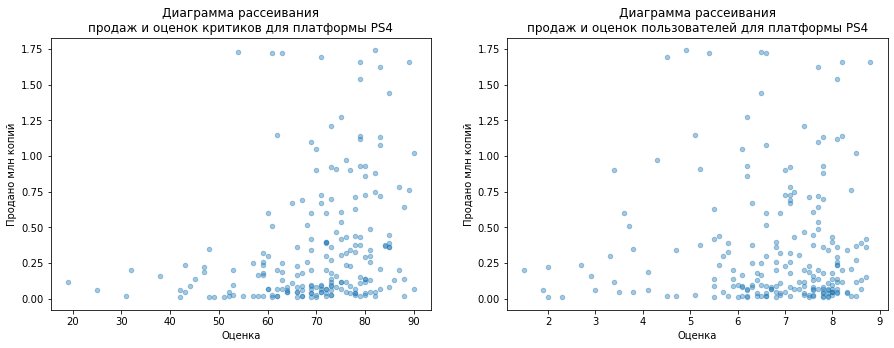

```python
plt.subplots(figsize=(15,5))
selected_columns = ['critic_score', 'user_score']
scores = ['оценок критиков', 'оценок пользователей']
for plot_num, column in enumerate(selected_columns):
    (data_actual.query('platform == "PS4" and total_sales <= 1.75')
          .plot(kind='scatter', ax=plt.subplot(1, len(selected_columns),plot_num+1), x=column, y='total_sales', alpha=0.4)
    )
    plt.title(f'Диаграмма рассеивания\nпродаж и {scores[plot_num]} для платформы PS4')
    plt.ylabel('Продано млн копий')
    plt.xlabel('Оценка')
```

На графике видно, что большая часть продаваемых игр имеет оценки критиков выше 60 и пользователей выше 5.5. Однако на диаграмме рассеивания продаж по оценкам пользователей это не так явно прослеживается. Здесь имеются отдельные значения с низкими оценками пользователй и высокими продажами.

Посчитаем коэффициенты корреляции для этих показателей.

```python
(data_actual.query('platform == "PS4" and total_sales <= 1.75')[['total_sales', 'critic_score', 'user_score']]
 .corr().sort_values(by='total_sales', ascending=False)
)
```

|  | total_sales | critic_score | user_score |
| --- | --- | --- | --- |
| total_sales | 1.000000 | 0.272624 | 0.011444 |
| critic_score | 0.272624 | 1.000000 | 0.628491 |
| user_score | 0.011444 | 0.628491 | 1.000000 |

Полученные коэффициенты подтверждают выводы по графику.

Между продажми и оценками критиков существует прямая зависимость. И она гораздо выше, чем зависимость продаж от оценок пользователей. Коэффициент корреляции оценки пользователей и продаж говорит практически об отстствии зависимости между этими показателями.

**Посмотрим так ли это по отношению к другим платформам. Посчитаем аналогичные показатели для платформ XOne, 3DS, PC. Значения продаж для расчетов будем брать в пределах границ нормальных значений.**

```python
(print('Границы нормальных значений продаж для платформы XOne',
       normal_borders(data_actual.loc[data_actual['platform'] == 'XOne'], 'total_sales'))
)
(print('Границы нормальных значений продаж для платформы 3DS',
       normal_borders(data_actual.loc[data_actual['platform'] == '3DS'], 'total_sales'))
)
(print('Границы нормальных значений продаж для платформы PC',
       normal_borders(data_actual.loc[data_actual['platform'] == 'PC'], 'total_sales'))
)
```

```
Границы нормальных значений продаж для платформы XOne (0, 1.6225)
Границы нормальных значений продаж для платформы 3DS (0, 0.6400000000000001)
Границы нормальных значений продаж для платформы PC (0, 0.53)
```

**Оценка влияния отзывов на продажи игр на платформе XOne**

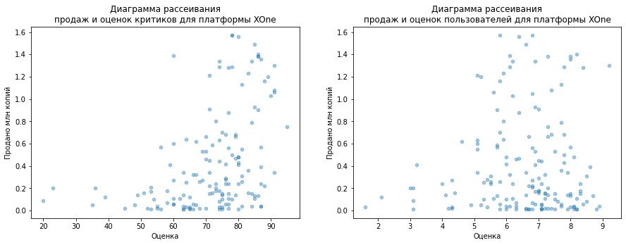

```python
plt.subplots(figsize=(15,5))
selected_columns = ['critic_score', 'user_score']
scores = ['оценок критиков', 'оценок пользователей']
for plot_num, column in enumerate(selected_columns):
    (data_actual.query('platform == "XOne" and total_sales <= 1.62')
          .plot(kind='scatter', ax=plt.subplot(1, len(selected_columns),plot_num+1), x=column, y='total_sales', alpha=0.4)
    )
    plt.title(f'Диаграмма рассеивания\nпродаж и {scores[plot_num]} для платформы XOne')
    plt.ylabel('Продано млн копий')
    plt.xlabel('Оценка')
```

Здесь также большая часть игр продается с оценками критиков выше 60 и пользователей выше 5,5. Кроме того, видно, что значения продаж игр с оценкой пользователей меньше 4,5 находятся в пределах до 0,5млн, а с оценкой критиков меньше 45 в пределах 0,3 млн.

Посчитаем коэффициенты корреляции.

```python
(data_actual.query('platform == "XOne" and total_sales <= 1.62')[['total_sales', 'critic_score', 'user_score']]
 .corr().sort_values(by='total_sales', ascending=False)
)
```

|  | total_sales | critic_score | user_score |
| --- | --- | --- | --- |
| total_sales | 1.000000 | 0.420134 | 0.059901 |
| critic_score | 0.420134 | 1.000000 | 0.543556 |
| user_score | 0.059901 | 0.543556 | 1.000000 |

Здесь более высокие коэффициенты корреляции по обоим оценкам, чем у платформы PS4. Однако также можно сделать вывод, что оценки критиков влияют на продажи гораздо сильнее, чем оценки пользователей.

**Оценка влияния отзывов на продажи игр на платформе 3DS**

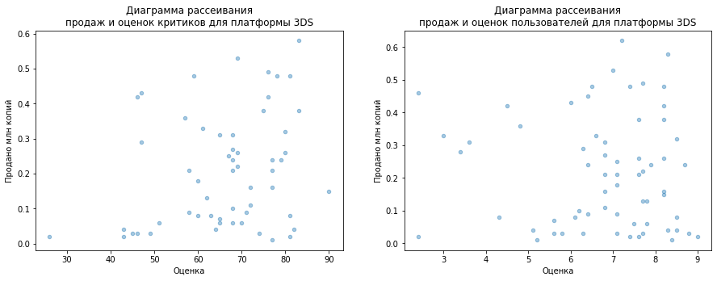

```python
plt.subplots(figsize=(15,5))
selected_columns = ['critic_score', 'user_score']
scores = ['оценок критиков', 'оценок пользователей']
for plot_num, column in enumerate(selected_columns):
    (data_actual.query('platform == "3DS" and total_sales <= 0.64')
          .plot(kind='scatter', ax=plt.subplot(1, len(selected_columns),plot_num+1), x=column, y='total_sales', alpha=0.4)
    )
    plt.title(f'Диаграмма рассеивания\nпродаж и {scores[plot_num]} для платформы 3DS')
    plt.ylabel('Продано млн копий')
    plt.xlabel('Оценка')
```

Здесь также большая часть игр продается с оценками выше 60 у критиков и выше 5,5 у пользователей. Однако рассеивание точек графика значительно больше и есть высокие продажи игр с низкими оценками как крититков, так и пользователей.

Посчитаем коэффициенты корреляции.

```python
(data_actual.query('platform == "3DS" and total_sales <= 0.64')[['total_sales', 'critic_score', 'user_score']]
 .corr().sort_values(by='total_sales', ascending=False)
)
```

|  | total_sales | critic_score | user_score |
| --- | --- | --- | --- |
| total_sales | 1.000000 | 0.259144 | -0.059978 |
| critic_score | 0.259144 | 1.000000 | 0.735057 |
| user_score | -0.059978 | 0.735057 | 1.000000 |

В случае с платформой 3DS также между продажами и оценками критиков прямая корреляция, хоть и не слишком высокая. А коэффициент корреляции между продажами и оценками пользователей получился отрицательным, но его величина говорит практически об отсутствии зависимости между этими показателями.

**Оценка влияния отзывов на продажи игр на платформе PC**

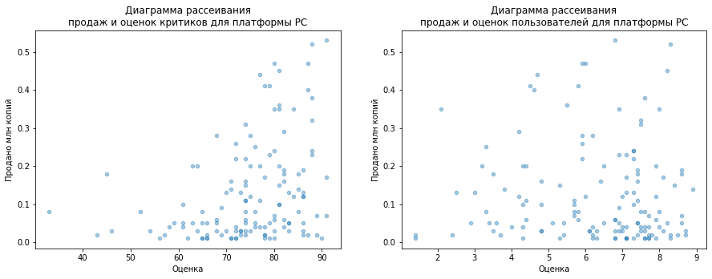

```python
plt.subplots(figsize=(15,5))
selected_columns = ['critic_score', 'user_score']
scores = ['оценок критиков', 'оценок пользователей']
for plot_num, column in enumerate(selected_columns):
    (data_actual.query('platform == "PC" and total_sales <= 0.53')
          .plot(kind='scatter', ax=plt.subplot(1, len(selected_columns),plot_num+1), x=column, y='total_sales', alpha=0.4)
    )
    plt.title(f'Диаграмма рассеивания\nпродаж и {scores[plot_num]} для платформы PC')
    plt.ylabel('Продано млн копий')
    plt.xlabel('Оценка')
```

Здесь мы уже видим, что продажи, хоть и рассеяны в большей мере в областе высоких оценок как критиков, так и пользователей, но и в значениях оценок меньше средних достаточно много точек продаж. Особенно это относится к оценкам пользователей, тут сравнительно моного точек с высокими продажами и низкими оценками.

Посчитаем коэффициенты корреляции.

```python
(data_actual.query('platform == "PC" and total_sales <= 0.53')[['total_sales', 'critic_score', 'user_score']]
 .corr().sort_values(by='total_sales', ascending=False)
)
```

|  | total_sales | critic_score | user_score |
| --- | --- | --- | --- |
| total_sales | 1.000000 | 0.346080 | -0.041168 |
| critic_score | 0.346080 | 1.000000 | 0.413158 |
| user_score | -0.041168 | 0.413158 | 1.000000 |

Полученные коэффициенты подтверждают наши выводы. Есть небольшая прямая зависимость между оценками критиков и продажами. Корреляция между оценками пользователей и продажами опять получилась отрицательной, но ее величина очень мала, можно сказать, что зависимость отсутствует.

**Посмотрим в целом по всем платформам на зависимость продаж от отзывов пользователей и критиков.**

Сначала посчитаем границы нормальных значений для общих продаж.

```python
print('Границы нормальных значений продаж для всех платформ', normal_borders(data_actual, 'total_sales'))
```

```
Границы нормальных значений продаж для всех платформ (0, 0.955)
```

Построим диаграммы рассеивания

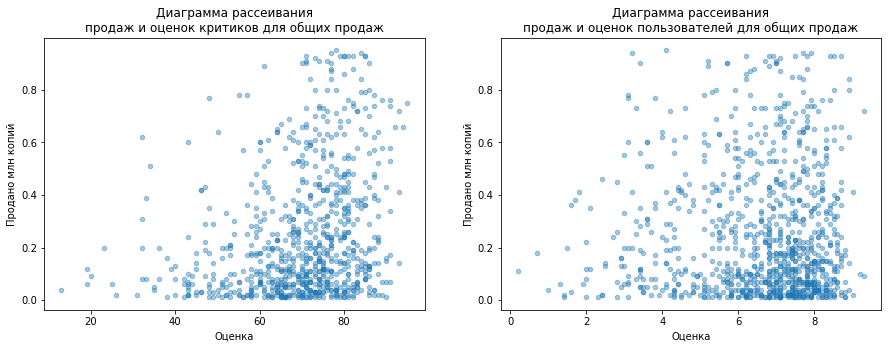

```python
plt.subplots(figsize=(15,5))
selected_columns = ['critic_score', 'user_score']
scores = ['оценок критиков', 'оценок пользователей']
for plot_num, column in enumerate(selected_columns):
    (data_actual.query('total_sales <= 0.955')
          .plot(kind='scatter', ax=plt.subplot(1, len(selected_columns),plot_num+1), x=column, y='total_sales', alpha=0.4)
    )
    plt.title(f'Диаграмма рассеивания\nпродаж и {scores[plot_num]} для общих продаж')
    plt.ylabel('Продано млн копий')
    plt.xlabel('Оценка')
```

В целом можно сделать, те же выводы, что и при рассмотрении зависимости продаж от оценок по платформам. Видно, что более высокие продажи соответствуют высоким оценкам критиков. В оценках пользователей рассеивание выше, и есть точки высоких продаж с более низкими оценками.

Посчитаем коэффициенты корреляции.

```python
(data_actual.query('total_sales <= 0.955')[['total_sales', 'critic_score', 'user_score']]
 .corr().sort_values(by='total_sales', ascending=False)
)
```

|  | total_sales | critic_score | user_score |
| --- | --- | --- | --- |
| total_sales | 1.000000 | 0.265043 | 0.012450 |
| critic_score | 0.265043 | 1.000000 | 0.554318 |
| user_score | 0.012450 | 0.554318 | 1.000000 |

Полученные коэффициенты подтверждают выводы по графику. Между продажами и оценками критиков прямая зависимость. И она гораздо выше зависимости продаж от оценок пользователей. Можно сказать что зависимость продаж от оценок пользователей практически отсутствует.

**Вывод**

В целом для всех платформ характерна прямая зависимость продаж от оценок критиков, тогда как корреляция между продажами и оценками пользователей практически отсутствует.

#### Исследование продаж игр по жанрам.

Посмотрим на общее распределение игр по жанрам

```python
ganre_actual = data_actual.groupby('genre').agg({'total_sales':['count','sum', 'mean']}).droplevel(0, axis=1)
ganre_actual.columns = ['games_count','total_sales', 'mean_sales']
ganre_actual['total_sales_%'] = round((ganre_actual['total_sales'] / ganre_actual['total_sales'].sum() * 100), 2)
ganre_actual['games_count_%'] = round((ganre_actual['games_count'] / ganre_actual['games_count'].sum() * 100), 2)
ganre_actual.sort_values(by='total_sales_%', ascending=False)
```

| genre | games_count | total_sales | mean_sales | total_sales_% | games_count_% |
| --- | --- | --- | --- | --- | --- |
| Action | 766 | 321.87 | 0.420196 | 29.51 | 34.30 |
| Shooter | 187 | 232.98 | 1.245882 | 21.36 | 8.37 |
| Sports | 214 | 150.65 | 0.703972 | 13.81 | 9.58 |
| Role-Playing | 292 | 145.89 | 0.499623 | 13.38 | 13.08 |
| Misc | 155 | 62.82 | 0.405290 | 5.76 | 6.94 |
| Platform | 74 | 42.63 | 0.576081 | 3.91 | 3.31 |
| Racing | 85 | 39.89 | 0.469294 | 3.66 | 3.81 |
| Fighting | 80 | 35.31 | 0.441375 | 3.24 | 3.58 |
| Adventure | 245 | 23.64 | 0.096490 | 2.17 | 10.97 |
| Simulation | 62 | 21.76 | 0.350968 | 2.00 | 2.78 |
| Strategy | 56 | 10.08 | 0.180000 | 0.92 | 2.51 |
| Puzzle | 17 | 3.17 | 0.186471 | 0.29 | 0.76 |

Для наглядности построим график сопоставляющий доли проданных игр по жанрам в общих продажах и доли выпущенных игр по жанрам в общем количестве игр. Наиболее наглядно отличия отобразит столбчатая диаграмма.

А также график со средними продажами млн. копий, приходящимися на одну игру жанра. Здесь тоже подойдет столбчатая диаграмма.

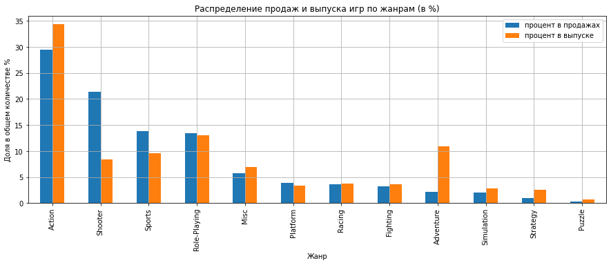

```python
(ganre_actual[['total_sales_%', 'games_count_%']]
 .sort_values(by='total_sales_%', ascending=False).plot(kind='bar', figsize=(15,5), grid=True)
)
plt.title('Распределение продаж и выпуска игр по жанрам (в %)')
plt.legend(['процент в продажах', 'процент в выпуске'])
plt.ylabel('Доля в общем количестве %')
plt.xlabel('Жанр')
plt.show()
```

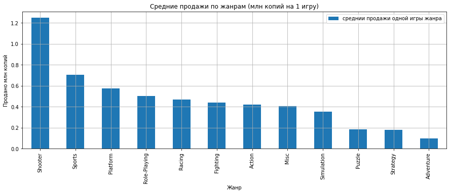

```python
(ganre_actual[['mean_sales']]
 .sort_values(by='mean_sales', ascending=False).plot(kind='bar', figsize=(15,5), grid=True)
)
plt.title('Средние продажи по жанрам (млн копий на 1 игру)')
plt.legend(['среднии продажи одной игры жанра'])
plt.ylabel('Продано млн копий')
plt.xlabel('Жанр')
plt.show()
```

В целом можно выделить четыре наиболее популярных жанра: "Action", "Shooter", "Sports", "Role-Playing". Их доля в общем количестве проданных игр составляет 78%. Самый популярный жанр, исходя из общего количества проданных копий "Action" (29,5% от общего количества проданных копий игр). На втором месте "Shooter" (21,4%).

Если смотреть на количество выпускаемых игр, то лидируют также игры в жанре "Action", но их доля в количестве выпускаемых игр несколько выше чем в продажах (34,3%). На втором месте игры жанра "Role-Playing" (13,08%), они занимают 4 место в общих продажах, но доли в продажах и выпуске практически одинаковые. Доля игры жанра "Shooter" в общем количестве выпускаемых игр всего 8,4% (5 место). Также следует обратить внимание на игры жанра "Adventure" их доля в количестве выпускаемых игр почти 11% (3 место), тогда как доля продаж этих игр всего 2,2% (9 место).

В результате описанных выше различий в количествах выпускаемых и продаваемых игр по жанрам, рассматривая среднее количество проданных млн.копий одной игры каждого жанра мы видим, что на первом месте игры жанра "Shooter" - средние продажи одной игры жанра 1,246 млн копий (что выше общих средних продаж - 0,488млн на 155%). На втором месте игры жанра "Sports" - в среднм продается 0,704 млн копий одной игры этого жанра (что выше общего среднего показателя на 45%). Игры жанра "Action", лидирующие в общих продажах, по средним продажм млн.копий на одну игру жанра занимают лишь 7 место - средние продажи 0,420 млн копий (что на 14% ниже общих средних продаж). Самые низкие средние продажи у игр жанра "Adventure" - в среднем продается 0,096 млн копий одной игры жанра (что ниже общего среднего показателя на 80%).

### Вывод

В ходе исследовательского анализа, основываясь на данных по общему количеству выпускаемых игр, а также учитывая сроки жизни игровых платформ, определили актуальный период для исследования 2013-2016 годы.

В актуальном периоде мы выдилели две лидирующие по продажам платформы: PS4 и XOne. Также обратили внимание на платформы со стабильными ежегодными продажами - это PC, 3DS и PSV. По остальным платформам продажи в исследуемом периоде резко сокращаются. Две платформы полностью исчезли с рынка (DS и PSP).

Рассматривая разброс значений продаж игр в разбивке по платформам мы определили, что самый высокий медианный показатель по продажам в исследуемом периоде у платформы X360(0,265 млн копий игры). Медиана продаж у всех платформ ближе к нижней границы нормальных значений, значит, что значений продаж меньше медианы больше. Самый большой межквартильный интервал также у платформы X360, что говорит о высоком разбросе значений продаж по этой платформе. Для платформы PS4 также характерен большой разброс значений продаж. У платформы XOne разброс данных меньше чем у PS4.

Оценивая влияние отзывов пользователей и критиков на продажи, мы выяснили, что между оценкой критиков и продажами корреляция прямая и она выше, чем корреляция между оценками пользователей и продажами. Можно сказать, что оценка пользователей практически не оказывает влияния на продажи. Если рассматривать корреляцию между оценкой критиков и продажами, то для платформы XOne этот показатель самый высокий на 58% выше, чем общий показатель (XOne-0,42, общий-0,27) . Самый низкий показатель корреляции между оценками критиков и продажами для игр на платформе 3DS (коэффициент корреляции 0,26).

Что касается жанров компьютерных игр, то наибольшую долю в общих продажах составляют игры жанров "Action", "Shooter", "Sports" и "Role-Playing". Лидируют игры жанра "Action". Если же рассматривать среднее количество проданных копий на одну игру жанра, то здесь лидируют игры жанра "Shooter", игры жанра "Action" по этому показателю лишь на 7 месте.

## Исследовательский анализ продаж игр по регионам.

### Общие продажи игр по регионам.

Посмотрим как распределены продажи в целом по регионам. Для визуализации построи круговую диаграмму

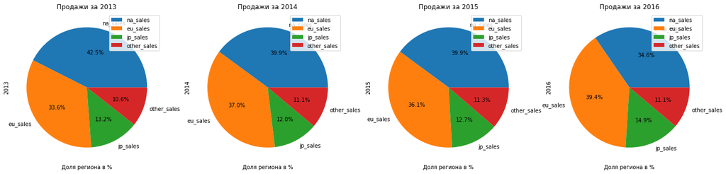

```python
region_sales =(
    data_actual.groupby('year_of_release')
    .agg({'na_sales':'sum', 'eu_sales':'sum', 'jp_sales':'sum', 'other_sales':'sum'}).T
)
plt.subplots(figsize=(23,6))
selected_columns = ['2013', '2014', '2015', '2016']

for plot_num, column in enumerate(selected_columns):
    (region_sales
     .plot(kind='pie',y=column, ax=plt.subplot(1, len(selected_columns),plot_num+1), autopct='%1.1f%%', grid=True)
    )
    plt.title(f'Продажи за {column}')

    plt.xlabel('Доля региона в %')
```

```python
#region_sales = region_sales.rename_axis('region')
region_sales['total_sales'] = region_sales['2013'] + region_sales['2014'] + region_sales['2015'] + region_sales['2016']
region_sales['total_sales_%'] = round((region_sales['total_sales'] / region_sales['total_sales'].sum() * 100), 2)
region_sales
```

| year_of_release | 2013 | 2014 | 2015 | 2016 | total_sales | total_sales_% |
| --- | --- | --- | --- | --- | --- | --- |
| na_sales | 153.65 | 132.27 | 106.86 | 44.93 | 437.71 | 40.13 |
| eu_sales | 121.55 | 122.74 | 96.72 | 51.22 | 392.23 | 35.96 |
| jp_sales | 47.69 | 39.69 | 34.09 | 19.31 | 140.78 | 12.91 |
| other_sales | 38.35 | 36.83 | 30.31 | 14.48 | 119.97 | 11.00 |

Если рассматривать данные за 4 года, то в целом наибольшую долбю продаж занимает рынок Северной Америки 40%, на втором месте рынок Европы 36%, Рынки Япониии и других стран занимают 13 и 11% соответственно.

На диаграммах по годам видно, что доля рынка Европы растет и к 2016 году составляет уже 39%, а доля рынка Северной Америки сокращается и в 2016 году составляет уже 35%. Также можно сказать, что в 2016 году выросла доля продаж в Японии (составляет почти 15%). Доля продаж в других странах остается на уровне около 11%.

### Самые популярные платформы по регионам продаж.

Посмотрим на популярные платформы по регионам. Построим столбчатую диаграмму по продажам для пяти самых популярных платформ по каждому региону.

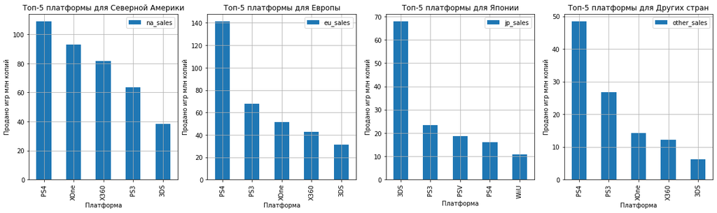

```python
plt.subplots(figsize=(20,5))
selected_columns = ['na_sales', 'eu_sales', 'jp_sales', 'other_sales']
regions = ['Северной Америки', 'Европы', 'Японии', 'Других стран']
for plot_num, column in enumerate(selected_columns):
    (data_actual.groupby('platform').agg({column:'sum'}).
     sort_values(by=column, ascending=False).head(5)
     .plot(kind='bar', ax=plt.subplot(1, len(selected_columns),plot_num+1), grid=True)
    )
    plt.title(f'Топ-5 платформы для {regions[plot_num]}')
    plt.ylabel('Продано игр млн копий')
    plt.xlabel('Платформа')
```

```python
regions = ['Северной Америке', 'Европе', 'Японии', 'Других странах']
i=0
for column in selected_columns:
    genres_by_region = (data_actual.groupby('platform').agg({column:'sum'}).
     sort_values(by=column, ascending=False)
    )
    #display(genres_by_region)
    genres_by_region['per'] = round((genres_by_region[[column]] / genres_by_region[[column]].sum() * 100), 2)

    #print (f'Топ-5 жанров по продажам в {regions[i]}')
    display(f'Топ-5 платформ по продажам игр в {regions[i]}', genres_by_region.head(5))
    print()
    i=i+1
```

```
'Топ-5 платформ по продажам игр в Северной Америке'
```

| platform | na_sales | per |
| --- | --- | --- |
| PS4 | 108.74 | 24.84 |
| XOne | 93.12 | 21.27 |
| X360 | 81.66 | 18.66 |
| PS3 | 63.50 | 14.51 |
| 3DS | 38.20 | 8.73 |

```
'Топ-5 платформ по продажам игр в Европе'
```

| platform | eu_sales | per |
| --- | --- | --- |
| PS4 | 141.09 | 35.97 |
| PS3 | 67.81 | 17.29 |
| XOne | 51.59 | 13.15 |
| X360 | 42.52 | 10.84 |
| 3DS | 30.96 | 7.89 |

```
'Топ-5 платформ по продажам игр в Японии'
```

| platform | jp_sales | per |
| --- | --- | --- |
| 3DS | 67.81 | 48.17 |
| PS3 | 23.35 | 16.59 |
| PSV | 18.59 | 13.21 |
| PS4 | 15.96 | 11.34 |
| WiiU | 10.88 | 7.73 |

```
'Топ-5 платформ по продажам игр в Других странах'
```

| platform | other_sales | per |
| --- | --- | --- |
| PS4 | 48.35 | 40.30 |
| PS3 | 26.77 | 22.31 |
| XOne | 14.27 | 11.89 |
| X360 | 12.11 | 10.09 |
| 3DS | 6.28 | 5.23 |

Во всех регионах, кроме Японии на первом месте по продажам игры для платформы PS4, самая большая доля этих игр в продажах Других стран - 40,3%, самая маленькая в Северной Америке - 24,8%. В Японии игры для этой платформы находятся на 4-м месте (их доля в продажах - 11,3%).

На первом месте по продажам в Японии игры на платформе 3DS, их доля 48,2%- почти половина всех игр. В остальных регионах игры для этой платформы на 5-м месте по продажам (их доля от 5,2 до 8,7%).

На втором месте по продажам в Северной Америке игры на платформе XOne (их доля 21,3%). В остальных регионах на 2-м месте по продажам игры для платформы PS3 (наибольшая доля в других странах-22,3%, в Европе-17,3%, в Японии-16,6%). В Северной Америке доля продаж игр на этой платформе 14,5% (они на 4-м месте по продажам в этой стране).

На 3-м месте по продажам в Северной Америке игры на платформе X360 - 18,7% всех продаж. В Европе и Других странах на третьем месте игры для платформы XOne (13,2% и 11,9% соответственно). В Японии на третьем месте по продажам игры для платформы PSV (их доля 13,2%). В топ-5 по другим регионам эта платформа не попала.

На 4-м месте по продажам в Европе и Других странах игры для платформы X360 (доли 10,8% и 10,1% соответственно). В Японии игры для этой платформы в топ-5 не попали, как и игры для платформы XOne.

На 5-м месте по продажам в Японии находятся игры для платформы WiiU (доля 7,7%). Этой платформы также нет в топ-5 остальных регионов.

### Самые популярные жанры по регионам продаж.

Посмотрим на популярные жанры по регионам. Построим столбчатую диаграмму для пяти самых популярных жанров по каждому региону.

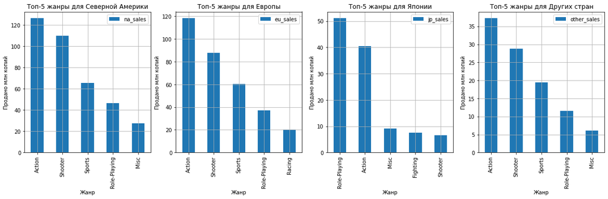

```python
plt.subplots(figsize=(20,5))
selected_columns = ['na_sales', 'eu_sales', 'jp_sales', 'other_sales']
regions = ['Северной Америки', 'Европы', 'Японии', 'Других стран']
for plot_num, column in enumerate(selected_columns):
    (data_actual.groupby('genre').agg({column:'sum'}).
     sort_values(by=column, ascending=False).head(5)
     .plot(kind='bar', ax=plt.subplot(1, len(selected_columns),plot_num+1),
           #color=(['pink'], ['red'], ['green'], ['blue'], ['cyan']),
           #palette='hls',
           grid=True)
    )
    plt.title(f'Топ-5 жанры для {regions[plot_num]}')
    plt.ylabel('Продано млн копий')
    plt.xlabel('Жанр')
```

Выведем на экран таблицы суммами и долями продаж самых популярных жанров по регионам.

```python
regions = ['Северной Америке', 'Европе', 'Японии', 'Других странах']
i=0
for column in selected_columns:
    genres_by_region = (data_actual.groupby('genre').agg({column:'sum'}).
     sort_values(by=column, ascending=False)
    )
    #display(genres_by_region)
    genres_by_region['per'] = round((genres_by_region[[column]] / genres_by_region[[column]].sum() * 100), 2)

    #print (f'Топ-5 жанров по продажам в {regions[i]}')
    display(f'Топ-5 жанров по продажам в {regions[i]}', genres_by_region.head(5))
    print()
    i=i+1
```

```
'Топ-5 жанров по продажам в Северной Америке'
```

| genre | na_sales | per |
| --- | --- | --- |
| Action | 126.05 | 28.80 |
| Shooter | 109.74 | 25.07 |
| Sports | 65.27 | 14.91 |
| Role-Playing | 46.40 | 10.60 |
| Misc | 27.49 | 6.28 |

```
'Топ-5 жанров по продажам в Европе'
```

| genre | eu_sales | per |
| --- | --- | --- |
| Action | 118.13 | 30.12 |
| Shooter | 87.86 | 22.40 |
| Sports | 60.52 | 15.43 |
| Role-Playing | 36.97 | 9.43 |
| Racing | 20.19 | 5.15 |

```
'Топ-5 жанров по продажам в Японии'
```

| genre | jp_sales | per |
| --- | --- | --- |
| Role-Playing | 51.04 | 36.26 |
| Action | 40.49 | 28.76 |
| Misc | 9.20 | 6.54 |
| Fighting | 7.65 | 5.43 |
| Shooter | 6.61 | 4.70 |

```
'Топ-5 жанров по продажам в Других странах'
```

| genre | other_sales | per |
| --- | --- | --- |
| Action | 37.20 | 31.01 |
| Shooter | 28.77 | 23.98 |
| Sports | 19.45 | 16.21 |
| Role-Playing | 11.48 | 9.57 |
| Misc | 6.09 | 5.08 |

Как видно В Северной Америке, Европе и других странах пятерки самых популярных жанров практически одинаковые. На первом месте в этих регионах жанр "Action", на втором "Shooter", на третьем и четвертом "Sports" и "Role-Playing" соответственно. Отличается только пятая позиция, в Северной америке и Других странах это "Misc", в Европе - "Racing".

### Влияние рейтинга ESRB на продажи в отельном регионе.

Для того, чтобы оценить влияние рейтинга ESRB на продажи по регионам посмотрим на средние и медианные значения продаж в зависимосте от рейтинга в общих продажах и в продажах по каждому региону.

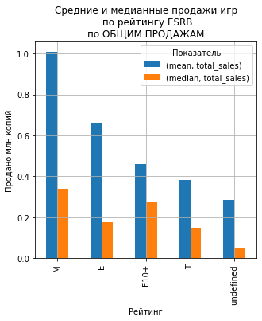

```python
(data_actual
 .pivot_table(index='rating', values='total_sales', aggfunc=['mean', 'median'])
 .sort_values(by=('mean', 'total_sales'), ascending=False)
 .plot(kind='bar',figsize=(5,5) , grid=True)
)
plt.title('Средние и медианные продажи игр\n по рейтингу ESRB\nпо ОБЩИМ ПРОДАЖАМ')
plt.legend(title='Показатель')
plt.ylabel('Продано млн копий')
plt.xlabel('Рейтинг')
plt.show()
```

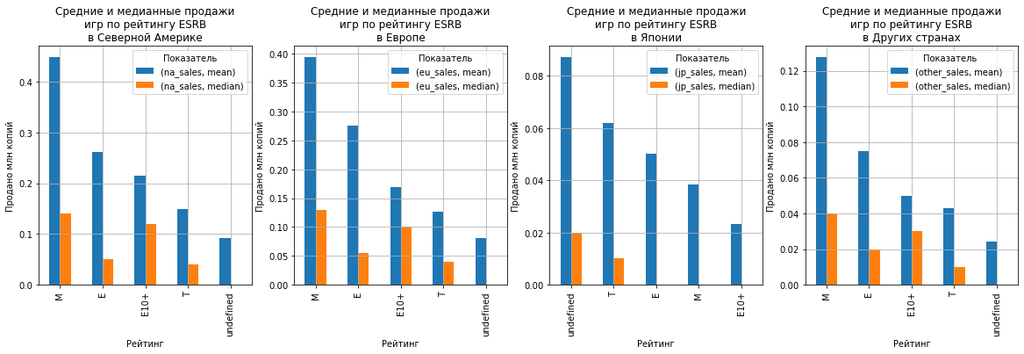

```python
plt.subplots(figsize=(20,5))
selected_columns = ['na_sales', 'eu_sales', 'jp_sales', 'other_sales']
regions = ['Северной Америке', 'Европе', 'Японии', 'Других странах']
for plot_num, column in enumerate(selected_columns):
    (data_actual.groupby('rating').agg({column:['mean','median']})
     .sort_values(by=( column, 'mean'), ascending=False)
     .plot(kind='bar', ax=plt.subplot(1, len(selected_columns),plot_num+1), grid=True)
    )
    plt.title(f'Средние и медианные продажи\n игр по рейтингу ESRB \nв {regions[plot_num]}')
    plt.ylabel('Продано млн копий')
    plt.xlabel('Рейтинг')
    plt.legend(title='Показатель')
```

```python
(data_actual.groupby('rating')
 .agg({'na_sales':['mean','median'], 'eu_sales':['mean','median'], 'jp_sales':['mean','median'],
       'other_sales':['mean','median'], 'total_sales':['mean','median'],})
 .sort_values(by=( 'total_sales', 'mean'), ascending=False)
 .round(3)
)
```

| rating | na_sales mean | na_sales median | eu_sales mean | eu_sales median | jp_sales mean | jp_sales median | other_sales mean | other_sales median | total_sales mean | total_sales median |
| --- | --- | --- | --- | --- | --- | --- | --- | --- | --- | --- |
| M | 0.448 | 0.14 | 0.394 | 0.130 | 0.038 | 0.00 | 0.127 | 0.04 | 1.007 | 0.340 |
| E | 0.262 | 0.05 | 0.276 | 0.055 | 0.050 | 0.00 | 0.075 | 0.02 | 0.663 | 0.175 |
| E10+ | 0.215 | 0.12 | 0.169 | 0.100 | 0.023 | 0.00 | 0.050 | 0.03 | 0.458 | 0.275 |
| T | 0.150 | 0.04 | 0.126 | 0.040 | 0.062 | 0.01 | 0.043 | 0.01 | 0.380 | 0.150 |
| undefined | 0.092 | 0.00 | 0.081 | 0.000 | 0.087 | 0.02 | 0.024 | 0.00 | 0.283 | 0.050 |

Как видно из графиков, и сводной таблицы, игры без рейтинга ESRB имеют наименьшие средние и медианные продажи в целом по выборке. Это характерно для всех стран кроме Японии. Также можно обратить внимание, что медианы по играм без рейтинга в Северной Америке, Европе и Других странах равны 0, это значит, что как минимум половина из имеющихся в продаже игр без рейтинга в этих странах точно не продаются. На первом месте по средним и медианным продажам в этих регионах игры с рейтингом М (для взрослых старше 17 лет). Далее по средним показателям идут игры с рейтингом E (для всех), а по медианным Е10+ (для всех от 10 лет) значит по этому рейтингу более высокие продажи на одну игру встречаются все таки чаще. Четвертое место и по средним и по медианным продажам занимают игры с рейтингом Т (для подростков).

Можно сказать, что присвоение рейтинга ESRB не влияет на продажи игр в Японии. Здесь максимальные средние и медианные продажи по играм без рейтинга. На втором месте по продажм в Японии игры с рейтингом Т (для подростков). По остальным рейтингам медианные продажи в Японии равны 0, значит таких игр продается в этой стране меньше половины существующих на рынке.

Еще стоит отметить, что средние значения заметно выше медианных. На них влияют высокие продажи отдельных, популярных игр.

### Вывод

Если сравнивать топ-5 самых популярных платформ по регионам можно сделать следующие выводы:

- В Европе и Других странах пятерки самых популярных платформ одинаковые - на первом месте PS4. Похожий рейтинг и у продаж в Северной Америке, там тоже в лидерах PS4, отличается второе место, в Северной Америке на вторм месте XOne, в Европе и Других странах PS3, XOne на 3-м месте. В целом предпочтения пользователей этих регионов схожи.
- Большие отличия наблюдаются в предпочтениях пользователей Японии. На первом месте в этом регионе платформа 3DS с долей 48,2%. В остальных регионах эта платформа лишь на 5-м месте. В топ-5 платформ Японии не попали популярные в других регионах платформы XOne и X360. И, наооборот, платформы PSV и WiiU есть только в топ-5 этой страны.

Рассмотрев топ-5 жанров игр по регионам, можно сделать выводы:

- Предпочтения пользователей Северной Америки, Европы и Других стран очень похожи. На первом месте по популярности в этих регионах игры жанра "Action". Различаются лишь пятые по популярности жанры - в Северной америке и Других странах это "Misc", в Европе - "Racing".
- Кардинально отличаются жанровые предпочтения пользователей Японии. Здесь на первом месте с очень высокой долей продаж (36%) игры жанра "Role-Playing", не попали в топ-5 жанров этой страны игры в жанре "Sports" (в других регионах этот жанр на 3-м месте). Игры в жанре "Shooter" на последнем месте в топ-5 Японии, тогда как в других регионах этот жанр на 2-м месте по популярности.

Что касается влияние рейтинга ESRB на продажи, изучив данные можно сделать следующие выводы:

- Этот рейтинг важен для стран Северной Америки, Европы и Других стран. По этим регионам самый низкие средние продажи игр без рейтинга, а медианные продажи равны 0.
- Для Японии характерна другая картина. Здесь игры без рейтинга самые продаваемые по средним и медианным продажам. А большая часть игр с присвоенным рейтингом (кроме рейтинга Т) имеет нулевые медианные продажи.

## Проверка гипотез.

### Проверка гипотезы о том, что средние пользовательские рейтинги платформ Xbox One и PC одинаковые.

Посчитаем средние оценки пользователей для платформ Xbox One и PC

```python
(data_actual.query('(platform == "PC" or platform == "XOne") and user_score >=2.8' ).groupby('platform')
 .agg({'user_score':['count','mean','var']})
)
```

| platform | user_score count | user_score mean | user_score var |
| --- | --- | --- | --- |
| PC | 149 | 6.441611 | 2.382176 |
| XOne | 180 | 6.573333 | 1.681073 |

Проверка гипотез о равенстве средних двух генеральных совокупностей осуществляется с помощью метода `scipy.stats.ttest_ind`.

**Нулевая гипотеза** Средние пользовательские рейтинги платформ Xbox One и PC равны.

**Альтернативная гипотеза** Средние пользовательские рейтинги платформ Xbox One и PC различаются.

Для более корректного проведения t-теста уберем из пользовательских рейтингов аномально большие или маленькие значения. Это также позволит при проведении теста не учитывать данные с незаполненными значениями оценок. Посчитаем границы нормальных значений для оценок пользователей.

```python
normal_borders(data_actual, 'user_score')
```

```
(2.8, 10.8)
```

```python
alpha=0.05

results =(
    st.ttest_ind(data_actual.loc[(data_actual['platform'] == 'XOne') & (data_actual['user_score']>=2.8), 'user_score'],
                        data_actual.loc[(data_actual['platform'] == 'PC')
                                        & (data_actual['user_score']>=2.8), 'user_score'], equal_var=False)
)
print('p-значение:', results.pvalue)
if results.pvalue < alpha:
    print('Отвергаем нулевую гипотезу')
else:
    print('Не получилось отвергнуть нулевую гипотезу')
```

```
p-значение: 0.4085271216168236
Не получилось отвергнуть нулевую гипотезу
```

Хотя средние оценки пользователей для платформ PC и XBox One отличаются, вероятность того, что эти различия случайны 40% и выше. Поэтому гипотеза о том, что средние оценки пользователей для этих двух платформ одинаковы не может быть отвергнута.

### Проверка гипотезы о том, что средние пользовательские рейтинги жанра "Action" и "Sport" различаются.

Посмотрим на средние пользователеьские рейтинге в выборке по этим жанрам.и

```python
(data_actual.query('(genre == "Action" or genre == "Sports") and user_score >=2.8').groupby('genre')
 .agg({'user_score':['count','mean','var']})
)
```

| genre | user_score count | user_score mean | user_score var |
| --- | --- | --- | --- |
| Action | 384 | 6.896094 | 1.524502 |
| Sports | 147 | 5.546939 | 2.239905 |

Используем метод проверки гипотез о равенстве средних двух генеральных совокупностей `scipy.stats.ttest_ind`.

**Нулевая гипотеза** Средние пользовательские рейтинги игр жанра "Action" и "Sports" равны.

**Альтернативной гипотезой** Средние пользовательские рейтинги игр жанра "Action" и "Sports" различаются.

Тест также проведем, не включая оценок за пределами нормальных значений и незаполненные показатели.

```python
alpha=0.05

results =(
    st.ttest_ind(data_actual.loc[(data_actual['genre'] == 'Action') & (data_actual['user_score']>=2.8), 'user_score'],
                        data_actual.loc[(data_actual['genre'] == 'Sports')
                                        & (data_actual['user_score']>=2.8), 'user_score'], equal_var=False)
)
print('p-значение:', results.pvalue)
if results.pvalue < alpha:
    print('Отвергаем нулевую гипотезу')
else:
    print('Не получилось отвергнуть нулевую гипотезу')
```

```
p-значение: 6.280922242293399e-19
Отвергаем нулевую гипотезу
```

Вероятность того, что средние пользовательские рейтинги игр жанров "Action" и "Sports" одинаковые, меньше статистически значимой, значит у нас есть основания отвергнуть эту гипотезу и не отвергать альтернативную. Данные из выборки соответствуют этой гипотезе.

### Вывод

Если сравнивать средние значения в таблице, то мы видим, что средняя оценка пользователей игр на платформе XOne незначительно отличается от оценки игр на платформе PC. Более существенно отличаются средние оценки пользователей игр жанров "Action" и "Sports".

Проверка этих гипотез статистическими методами показала:

- Гипотеза о том, что средние оценки пользователей игр для платформ XOne и PC одинаковые не может быть отвергнута.
- Гипотеза о том, что средние оценки пользователей для игр жанров "Action" и "Sports" различаются также не может быть отвергнута. Вероятность того, что эти показатели одинаковы близка к 0.

## Общий вывод.

Задачей исследования было выявить закономерности, определяющие успешность игры, что позволит спланировать рекламные кампании, сделав ставку на потенциально популярный продукт.

В ходе анализа имеющихся данных мы определили актуальный период для исследования 2013-2016 г. Это решение обусловленно существенным спадом в количестве выпущенных игр начиная с 2012 г., а также сроком жизни игровых платформ (от 7 до 12 лет) и тем, что наибольшие продажи по платформам наблюдаются на 2-5 годы их существования.

На основе имеющихся данных за актуальный период выявлены наиболее популярные и потенциально прибыльные платформы для игр - это PS4 и XOne. Также стоит обратить внимание на платформы со стабильными продажами 3DS и PC.

При исследовании влияния оценок пользователей и критиков на продажи игр было выявлено следующее:

- Между оценкой критиков и продажами существует небольшая прямая корреляция (коэффициент 0,27) . Самый высокий показатель корреляции продаж с оценками критиков у платформы XOne (0,42).
- Между оценками пользователей и продажами корреляция практически отстутствует (общий коэффициент корреляции 0,01).Это характерно для всех популярных платформ.

Анализ продаж игр в зависимости от жанра показал:

- Если рассматривать общие продажи, то наибольшей популярностью пользуются игры жанра "Action", на втором месте жанр "Shooter", также в числе самых популярных жанров "Sports" и "Role-Playing". В целом продажи игр этих жанров составляют 78% общих продаж.
- При анализе средних показателей (продаж млн.копий на 1 игру жанра) самые высокие значения у игр жанра "Shooter" (на 155% выше среднего по выборке). А средний показатель продаж по играм жанра "Action" только на 7-м месте (ниже среднего по выборке на 14%). На 2-м месте по средним продажам одной игры - жанр "Sports".

Исследование продаж по регионам выявило следующие особенности:

- В целом по выборке наибольшую долю в продажах занимает Северная Америка, затем Европа, Япония и Другие страны. Если же рассматривать продажи по годам, то к 2016 г. большую долю уже составляют продажи в Европе. Также в 2016 г. немного увеличилась доля продаж в Японии.
- Пользователи стран Северной Америки, Европы и Других стран в целом выбирают одни и те же игровые платформы. Лидер в топ-5 платформ по этим странам PS4. Для пользователей из Японии характерны совершенно другие предпочтения. В этой стране наибольшей популярностью пользуется платформа 3DS. Эту платформу предпочитают 48% пользователей. Платформу PS4 выбирают лишь 11% пользователей из Японии.
- Что касается жанровых предпочтений пользователей из разных регионов, то здесь тоже наблюдаются схожие значения в топ-5 для Северной Америки, Европы и Других стран - лидируют игры жанра "Action", на втором месте жанр "Shooter", на третьем "Sports". Совершенно другие жанры выбирают пользователи из Японии. Здесь на первом месте игры жанра "Role-Playing", на втором - "Action". Игры в жанре "Shooter" только на 5-м месте в продажах Японии.
- Исследование влияния рейтинга ESRB на продажи показало, что этот рейтинг важен для пользователей из Северной Америки, Европы и Других стран. Здесь наименьшие средние продажи по играм без рейтинга, медианные равны 0. Наибольшей популярностью пользуются игры с рейтингом М (старше 17 лет). В продажах игр в Японии напротив максимальные средние и медианные показатели у игр без присвоенного рейтинга. На втором месте игры с рейтингом Т (для подростков). Медианы по продажм игр с другими рейтингами равны 0.

Также в ходе исследования были проверены статистическиме методами две гипотезы:

- Гипотеза о том, что средние пользовательские рейтинги платформ PC и XBox One одинаковы не может быть отвергнута. Вероятность того, что различия этих показателей в выборке случайны 40% и выше.
- Гипотеза о том, что средние пользовательские рейтинги жанра "Action" и "Sport" различаются также не может быть отвергнута. Вероятность того что эти показатели одинаковы близка к нулю.